# Redes Neurais Artificiais

Lista 3

Vítor Gabriel Reis Caitité - 2016111849

21/12/2020

## Questão 1

Um estudante de engenharia estava fazendo o estudo de um sistema e durante um intervalo de tempo ele observou na entrada (x) uma senoide diferente daquela encontrada na saída (y), o aluno concluiu que aquela senoide da entrada havia sido multiplicada por um termo e somada a outro de forma que y = a + b * x. O estudante então pediu a você para encontrar estes parâmetros utilizando os conceitos da Adaline que você aprendeu. Para isso ele te forneceu o tempo de amostragem Ex1 t , os pontos de entrada Ex1_x e a saída Ex1_y. Para achar os parâmetros você deverá usar 70% dos dados para treinamento e 30% para teste. Calcule o erro médio quadrático para as amostras de teste e plote o gráfico da saída, considerando os parâmetros encontrados, para todos os pontos da entrada. Quais são os parâmetros do modelo? Obs: Use as mesmas amostras que as Figuras a seguir usaram para treinamento e teste.

#### *Resolução:*

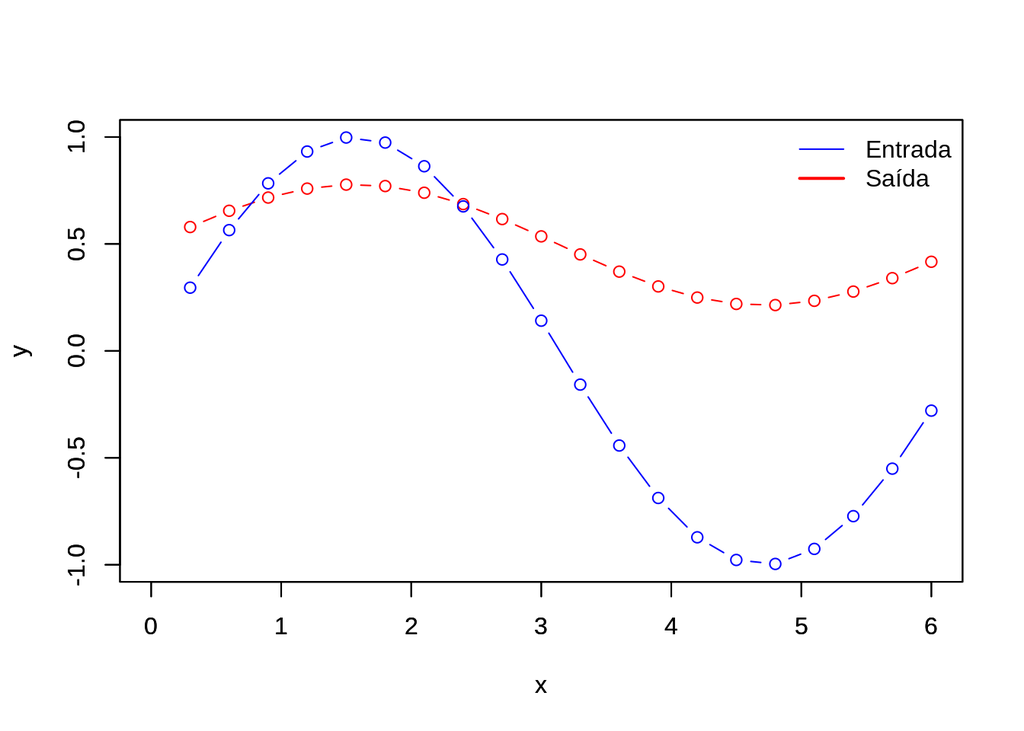

```r
rm(list = ls())

# Obtenção do tempo de amostragem:
t<-as.matrix(read.table("~/Documents/UFMG/9/Redes Neurais/listas/lista 3/dados/Ex1_t"))
# Obtenção dos pontos de entrada:
x<-as.matrix(read.table("~/Documents/UFMG/9/Redes Neurais/listas/lista 3/dados/Ex1_x"))
# Obtenção da saída:
y<-as.matrix(read.table("~/Documents/UFMG/9/Redes Neurais/listas/lista 3/dados/Ex1_y"))

# Classificando dados em dados de treinamento (1) ou teste (0)
class<-c(1, 1, 1, 1, 0, 1, 1, 0, 1, 1, 1, 0, 1, 0, 0, 1, 1, 0, 1, 1)
xtrain<-as.matrix(1:14, ncol = 1)
ytrain<-as.matrix(1:14, ncol = 1)
xtest<-as.matrix(1:6, ncol = 1)
ytest<-as.matrix(1:6, ncol = 1)
index_train = 1
index_test = 1
for (index in 1:20) {
  if((class[index] == 1)){
    xtrain[index_train, 1]<-x[index, 1]
    ytrain[index_train, 1]<-y[index, 1]
    index_train<-index_train+1
  } else {
    xtest[index_test, 1]<-x[index, 1]
    ytest[index_test, 1]<-y[index, 1]
    index_test<-index_test+1
  }
}

# Treinamento do modelo:
source("~/Documents/UFMG/9/Redes Neurais/exemplos/treinaadaline.R")
retlist<-trainadaline(xtrain, ytrain, 0.1, 0.01, 100, 1)
w<-retlist[[1]]
erro<-retlist[[2]]

# Plotando gráfico de saída
yhat = w[2]*x+w[1]
plot(t, yhat, type='b', xlab = 'x', ylab = 'y', xlim = c(0,6), ylim = c(-1,1), col = "red" )
par(new=T)
plot(t,x, type='b', xlab = 'x', ylab = 'y', xlim = c(0,6), ylim = c(-1,1), col = "blue")
legend("topright", legend=c("Entrada", "Saída"),
       lty=c(1,1), col=c(4,2), lwd=1:2, bty="n")
```

```r
#Calculando Erro Médio Quadrático
yhat_test = w[2]*xtest+w[1]
err=0
for (index in 1:6) {
  err=err+(yhat_test[index]-ytest[index])^2
}
err=err/6

print("O erro médio quadrático para as amostras de teste foi:")
```

```
## [1] "O erro médio quadrático para as amostras de teste foi:"
```

```r
print(err)
```

```
## [1] 0.0001867954
```

```r
print("Seja a saída dada por ŷ = w1*x + w0. Os parâmetros w0 e w1 são respectivamente:")
```

```
## [1] "Seja a saída dada por ŷ = w1*x + w0. Os parâmetros w0 e w1 são respectivamente:"
```

```r
print(w)
```

```
##           [,1]
## [1,] 0.4955293
## [2,] 0.2824526
```

## Questão 2

O mesmo estudante de engenharia ficou admirado com seus conhecimentos técnicos sobre Adaline e resolveu pedir mais um favor. Ele observou que o novo sistema que ele estava trabalhando era constituído de três sinais na entrada e que a saída era uma mistura destes sinais da entrada mais um ganho. Mas este estudante não sabia muito bem como era esta mistura de sinais, a única coisa que ele sabia era que: y = a+b*x1+c*x2+d*x3. O aluno amostrou então os sinais na entrada e na saída para o intervalo de [0.1π/ : 2π] e os armazenou nas variáveis t (tempos amostrais), x (entradas) e y (saída). Sendo que a primeira coluna de x é o sinal x 1 , a segunda x 2 e a terceira x 3 . Para achar os parâmetros você deverá usar 70% dos dados para treinamento e 30% para teste. Calcule o erro médio quadrático para as amostras de teste e plote o gráfico da saída, considerando os parâmetros encontrados, para todos os pontos da entrada. Quais são os parâmetros do modelo? Obs: Use as mesmas amostras que as Figuras a seguir usaram para treinamento e teste.

*Resolução:*

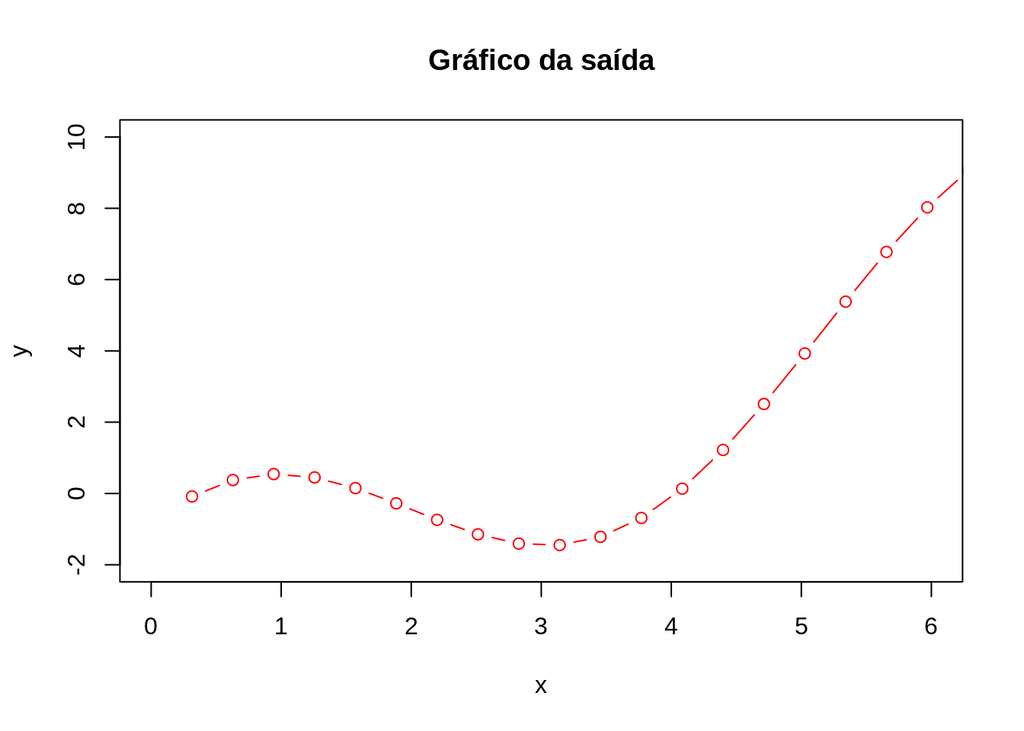

```r
rm(list = ls())

# Obtenção do tempo de amostragem:
t<-as.matrix(read.table("~/Documents/UFMG/9/Redes Neurais/listas/lista 3/dados/t"))
# Obtenção dos pontos de entrada:
x_all<-as.matrix(read.table("~/Documents/UFMG/9/Redes Neurais/listas/lista 3/dados/x"))
x1<-as.matrix(x_all[,1])
x2<-as.matrix(x_all[,2])
x3<-as.matrix(x_all[,3])
# Obtenção da saída:
y<-as.matrix(read.table("~/Documents/UFMG/9/Redes Neurais/listas/lista 3/dados/y"))



# Classificando dados em dados de treinamento (1) ou teste (0)
class<-c(1, 0, 1, 0, 1, 1, 1, 1, 1, 0, 1, 1, 1, 0, 1, 1, 1, 0, 0, 1)
xtrain<-matrix(nrow=14, ncol = 3)
ytrain<-as.matrix(1:14, ncol = 1)
xtest<-matrix(nrow=6, ncol = 3)
ytest<-as.matrix(1:6, ncol = 1)
index_train = 1
index_test = 1
for (index in 1:20) {
  if((class[index] == 1)){
    xtrain[index_train, 1]<-x1[index, 1]
    xtrain[index_train, 2]<-x2[index, 1]
    xtrain[index_train, 3]<-x3[index, 1]
    ytrain[index_train, 1]<-y[index, 1]
    index_train<-index_train+1
  } else {
    xtest[index_test, 1]<-x1[index, 1]
    xtest[index_test, 2]<-x2[index, 1]
    xtest[index_test, 3]<-x3[index, 1]
    ytest[index_test, 1]<-y[index, 1]
    index_test<-index_test+1
  }
}

# Treinamento do modelo:
source("~/Documents/UFMG/9/Redes Neurais/exemplos/treinaadaline.R")
retlist<-trainadaline(xtrain, ytrain, 0.1, 0.01, 100, 1)
w<-retlist[[1]]
erro<-retlist[[2]]

# Plotando gráfico de saída
yhat = w[4]*x3+w[3]*x2+w[2]*x1+w[1]
plot(t, yhat, type='b', xlab = 'x', ylab = 'y', xlim = c(0,6), ylim = c(-2,10), col = "red", main="Gráfico da saída" )
```

```r
#Calculando Erro Médio Quadrático
yhat_test = cbind(1, xtest) %*% w
err=0
for (index in 1:6) {
  err=err+(yhat_test[index]-ytest[index])^2
}
err=err/6

print("O erro médio quadrático para as amostras de teste foi:")
```

```
## [1] "O erro médio quadrático para as amostras de teste foi:"
```

```r
print(err)
```

```
## [1] 0.001710176
```

```r
print("Seja a saída dada por ŷ = w3*x3 +w2*x2 + w1*x1 + w0. Os parâmetros w0, w1, w2 e w3 são respectivamente:")
```

```
## [1] "Seja a saída dada por ŷ = w3*x3 +w2*x2 + w1*x1 + w0. Os parâmetros w0, w1, w2 e w3 são respectivamente:"
```

```r
print(w)
```

```
##           [,1]
## [1,] 1.5773744
## [2,] 0.9395441
## [3,] 2.0146833
## [4,] 2.9289660
```